# Introduktion

# Ett sammanhållet Dalarna

I ett sammanhållet Dalarna finns goda livsmiljöer som skapar en känsla av närhet. Det är ett Dalarna fyllt av engagemang, där människor upplever delaktighet och tillsammans bidrar till en hållbar utveckling. Det är ett inkluderande, jämställt, och jämlikt Dalarna där människor mår bra och där alla ges möjlighet att utvecklas.

Den sociala dimensionen av hållbarhet i det regionala utvecklingsarbetet handlar om att alla människor, utifrån sina behov och förutsättningar, ges likvärdiga möjligheter att delta i samhällsutvecklingen. Ju fler som känner sig delaktiga, desto mer utveckling kan åstadkommas.

## Trångboddhet

Goda livsmiljöer som upplevs som trygga och inkluderande är en förutsättning för att människor ska må bra. Olika platser i Dalarna har olika utmaningar och möjligheter, bland annat beroende på om det är platser med växande eller krympande befolkningsunderlag, att möta dessa behov. Indikatorn trångboddhet relaterar bland annat till prioriteringen i Dalastrategin om diversifierade boendeformer som i sin tur motverkar segregation och polarisering.

Antalet trångbodda i Dalarna har ökat under perioden från 2012 till 2020. I början på perioden var det 8812 individer i Dalarna som räknades som trångbodda enligt norm 2. Åtta år senare hade denna siffra ökat till 13 801 personer. Detta är dock lägre än toppnoteringen 2019 på 14 576 personer och kan vara början på en nedåtgående trend.

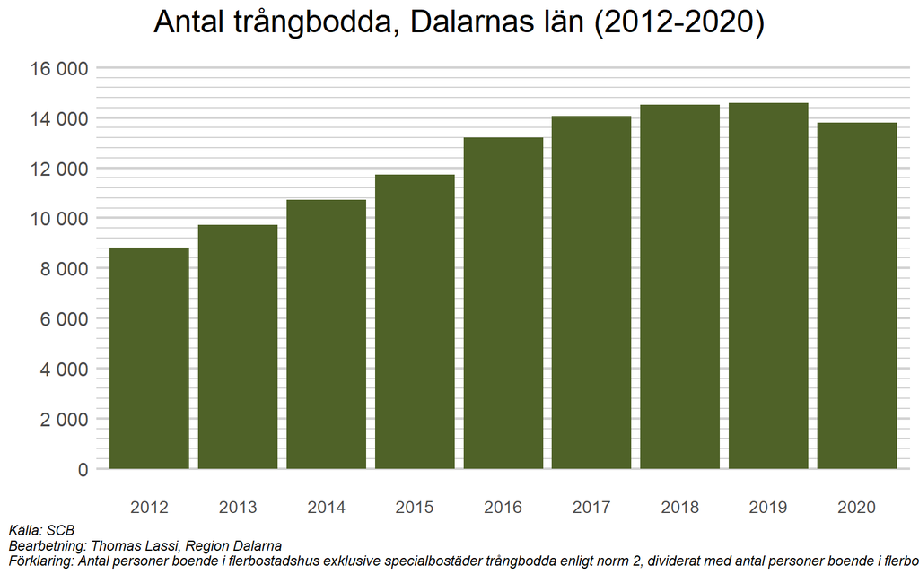

## Boendetyper

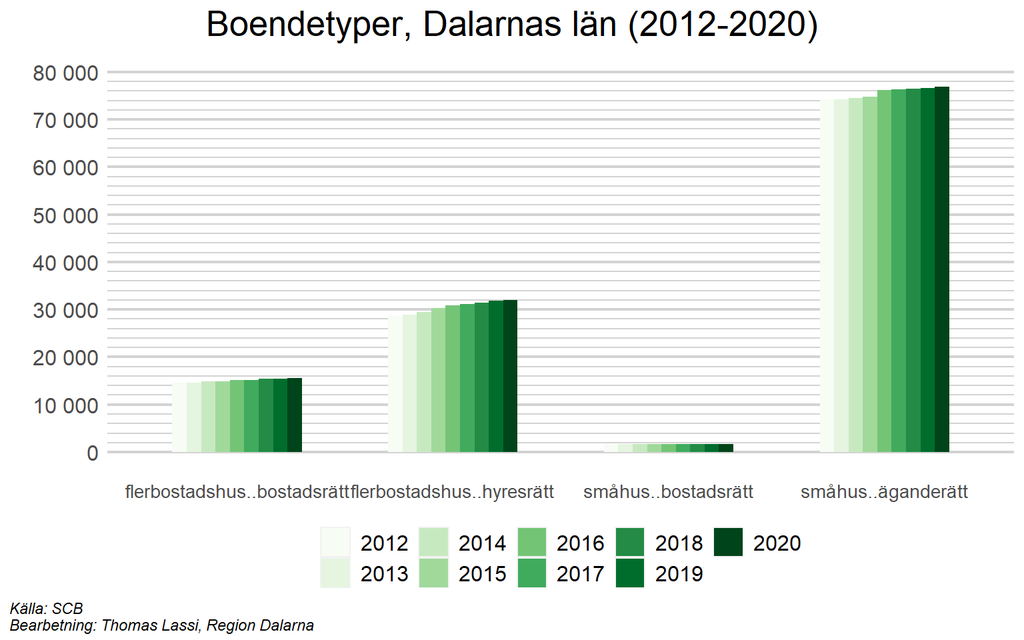

## Tillgång till service och tjänster

Olika platser i Dalarna har olika utmaningar och möjligheter, bland annat beroende på om det är platser med växande eller krympande befolkningsunderlag, att möta dessa behov. Med utgångspunkt, och som princip för genomförandet, att allt utvecklingsarbete ska vara platsbaserat ska den geografiska sammanhållningen stärkas och olika platsers förutsättningar och resurser tas tillvara. För utvecklingskraft i hela länet är det viktigt att säkra tillgången till service, vård, fritidsaktiviteter och kultur. Människor behöver ha en god tillgänglighet till såväl statlig som regional och kommunal service. Tillgången till service påverkar också människor levnadsvillkor och är viktigt för en plats attraktivitet.

Den här indikatorn presenterar två olika mått på tillgång till service; tillgång till grundskola samt tillgång till dagligvarubutik. Tillgång till grundskola har förbättras under perioden från 2010 till 2020. I början på perioden hade drygt 69,5 procent av alla invånare mellan 0-16 år en grundskola inom 2km från bostaden. 2020 hade motsvarande siffra ökat till 71,2 procent. Samma trend existerar inte för tillgång till dagligvarubutiker. Under samma period har andelen med en dagligvarubutik inom 2km från bostaden minskat från 66,3 procent till 65,3 procent.

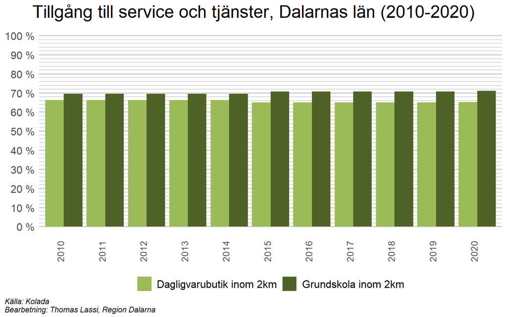

## Deltagande i det civila samhället

Att stärka sammanhållningen och med det den sociala hållbarheten, är viktigt för Dalarnas utveckling. Ett socialt hållbart samhälle tål påfrestningar, är anpassningsbart och resilient. Det är människorna i Dalarna som är regionens främsta resurs – som individer och del av familjer, andra gemenskaper, organisationer och företag. Människors känsla av sammanhang och delaktighet är centrala delar i det som ibland benämns socialt kapital.

Denna indikator visar andelen (%) invånare 18-80 år med lågt socialt deltagande. Indikatorn ingår även i BRP+, regionernas uppföljningssystem för hållbar utveckling och livskvalitet.

Perioden från 2007 till 2020 i Dalarna uppvisar ett antal olika trender och mönster. Från början på perioden genom 2015 steg andelen invånare mellan 18-80 år som uppgav att man deltagit i högst en aktivitet. Från 2016 och framåt sjunker andelen snabbt och är tillbaka på samma eller en lägre nivå än 2007. För 2020 uppger kvinnor och män nästan samma nivå av låg delaktighetet med 21 respektive 22 procent. För den manliga delen av befolkningen är detta en stor förbättring jämfört med fem år tidigare då andelen med lågt socialt deltagande uppgick till hela 29 procent.

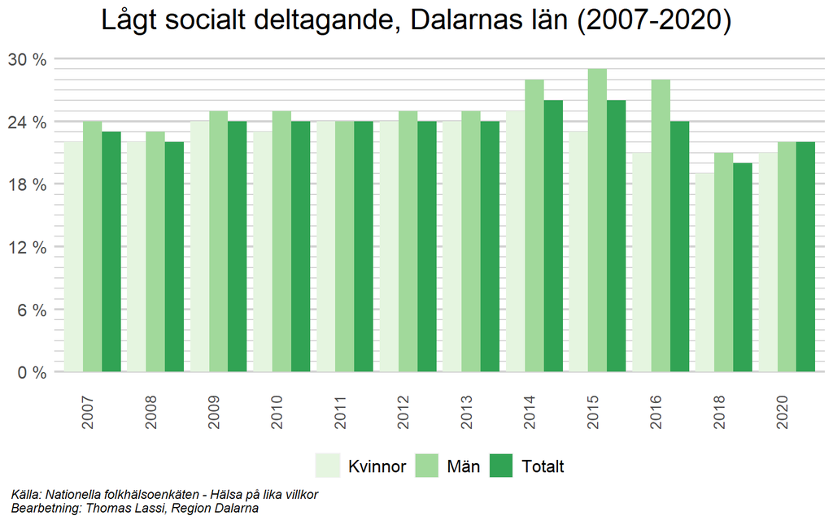

## Andel av hushåll som har tillgång till bredband

Tillgång till en snabb och robust digital infrastruktur är en grundförutsättning för att bo och verka i hela Dalarna. Fysiska och digitala mötesplatser gör att vi når både varandra och omvärlden. En av utmaningarna för Dalarna är en ojämnt fördelad digital infrastruktur. Att stärka och tillgängliggöra den digitala infrastrukturen för hela Dalarnas befolkning, oavsett plats, är avgörande för en lyckad digitalisering av samhället.

I Dalarna har andelen av befolkningen med tillgång till bredband ökat från drygt 47 procent 2015 till drygt 76 procent 2020. Andelen som redovisas här har tillgång till bredband om minst 100 Mbit/s och indikatorn inkluderas även i BRP+, regionernas uppföljningssystem för hållbar utveckling och livskvalitet.

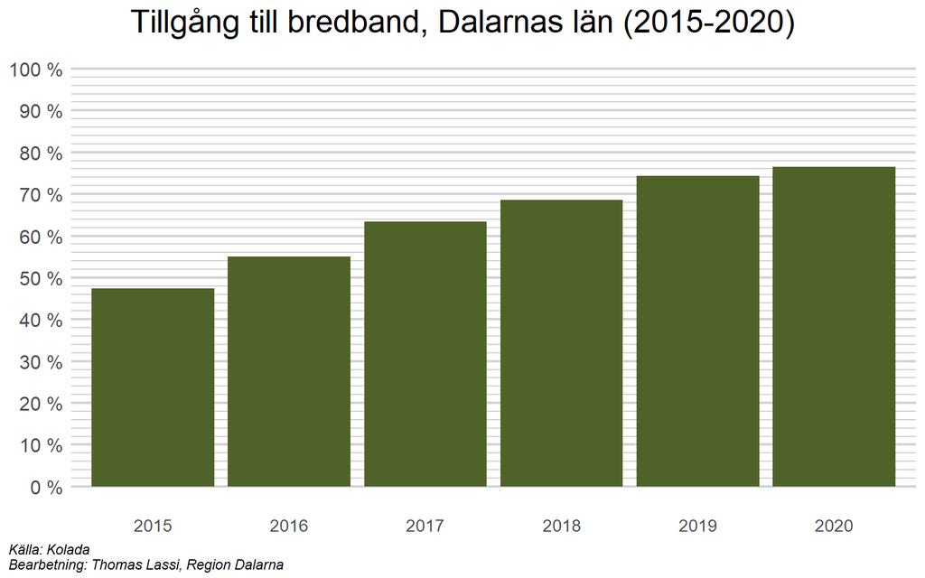

## Valdeltagande

Dalastrategin belyser vikten av att den representativa demokratins institutioner, såsom kommuner, region och myndigheter, är väl fungerande och uppbär människors tillit som centralt för en levande demokrati. Valdeltagande inkluderas därmed som en indikator för att följa upp invånarnas vilja och tro på de demokratiska institutionerna i länet. Valdeltagande ingår även som en indikator i BRP+, regionernas uppföljningssystem för hållbar utveckling och livskvalitet.

I Dalarna har valdeltagandet i både kommun-, region- samt riksdagsval ökat mellan valen 1998 och 2018. 1998 valde drygt 78,4 procent av invånarna i Dalarna att lägga en röst i kommunvalet. 2018 var motsvarande drygt 85,4 procent, en ökning med 7 procent. I varje val under tidsperioden har en högre andel valt att avlägga en röst i riksdagsvalet än i kommunvalet. Ännu färre väljer att rösta i landstings/regionvalet som har lägst valdeltagande.

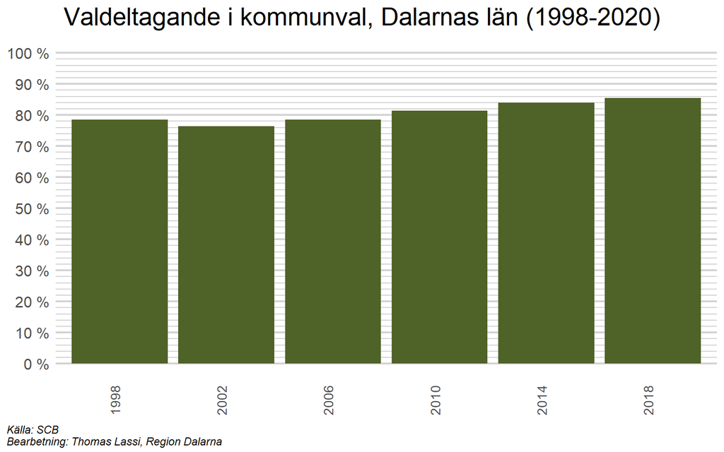

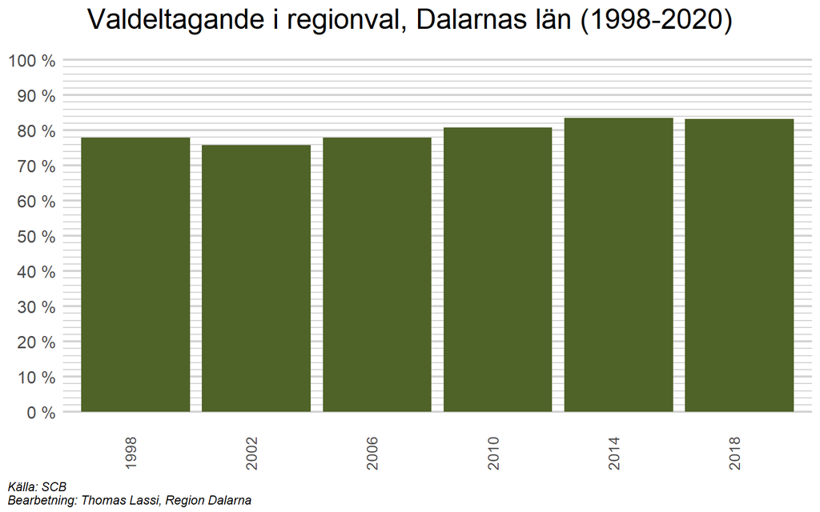

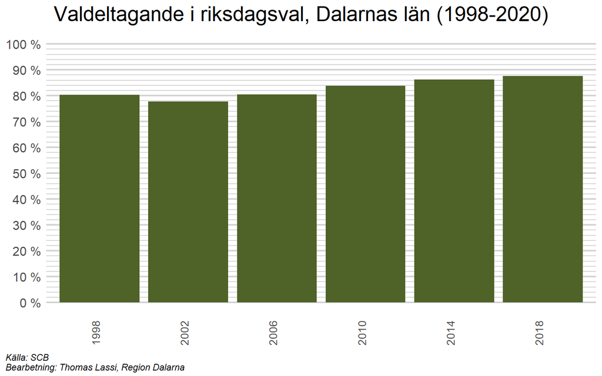

## Tillit till andra människor

Det är människorna i Dalarna som är regionens främsta resurs – som individer och del av familjer, andra gemenskaper, organisationer och företag. Människors känsla av sammanhang och delaktighet är centrala delar i det som ibland benämns socialt kapital. Ett högt socialt kapital är det kitt som får människor att trivas och är nödvändigt för att människor ska vilja bidra till samhällsutvecklingen. När människor känner sig som en del av samhället leder detta ofta också till en hög tillit till andra människor. Att den representativa demokratins institutioner, såsom kommuner, region och myndigheter, är väl fungerande och uppbär människors tillit är centralt för en levande demokrati. En hög tillit till andra underlättar även möten mellan människor där nya idéer kan uppstå och utvecklas. Ett samhälle med gott socialt kapital grundar för ett resilient samhälle, väl rustat att möta förändring och eventuella kriser.

Indikatorn som presenteras här nedan ger en bild av tillit i Dalarna. Indikatorn mäter andel (%) invånare 16-84 år med avsaknad av tillit till andra och inkluderas även i BRP+, regionernas uppföljningssystem för hållbar utveckling och livskvalitet. Tidsperioden från 2007 till 2021 visar på en sjunkande (positiv) trend för den här indikatorn. 2007 uppgav 28 procent av respondenterna i Dalarna en avsaknad av tillit till andra. 2021 var motsvarande siffra 26 procent. En högre andel av kvinnor uppger en avsaknad av tillit till andra men den positiva utvecklingen för indikatorn är till stor del en effekt av att andelen kvinnor med tillit till andra har ökat från 2007 till 2021.

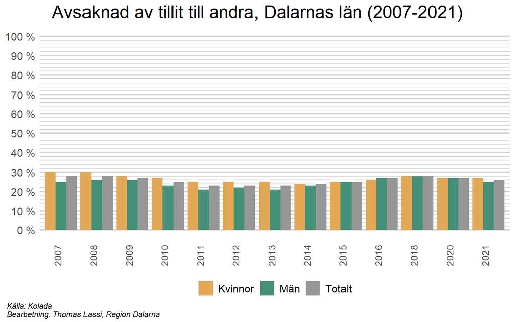

## Andel invånare i ekonomiskt utsatta hushåll

Ekonomiska klyftor mellan olika grupper i samhället är en utmaning för både Sverige och Dalarna. Om de socioekonomiska klyftorna blir alltför stora riskerar de att motverka sammanhållning, tillit och trygghet. Det riskerar i sin tur att försvaga demokratin, exempelvis genom systematiska skillnader i valdeltagande, faktiskt eller upplevt inflytande samt delaktighet och engagemang.

Andel barn som lever i ekonomiskt utsatta hushåll är ett mått på levnadsstandard som speglar möjligheterna för en av de mest utsatta grupperna i samhället. Detta mått ingår även i BRP+, regionernas uppföljningssystem för hållbar utveckling och livskvalitet. Med ekonomiskt utsatta avses hushåll med låg inkomst eller ekonomiskt bistånd (tidigare kallat socialbidrag). Med låg inkomst avses lägsta utgiftsnivå baserad på den socialbidragsnorm, som fastställdes på 1980-talet (med inflationsuppräkningar) och en norm för boendeutgifter. Om inkomsterna understiger dessa normer definieras detta som låg inkomst (för mer information om måttet, se Kolada.se).

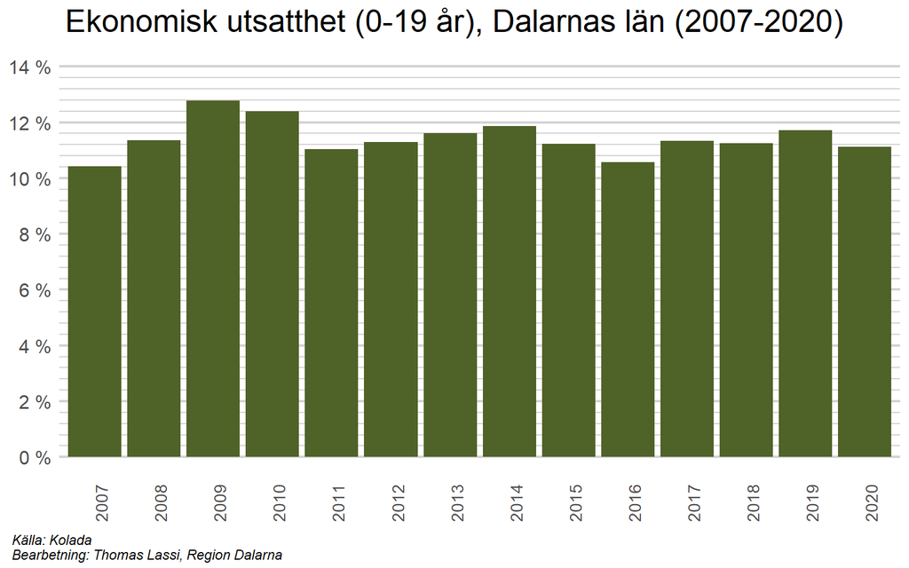

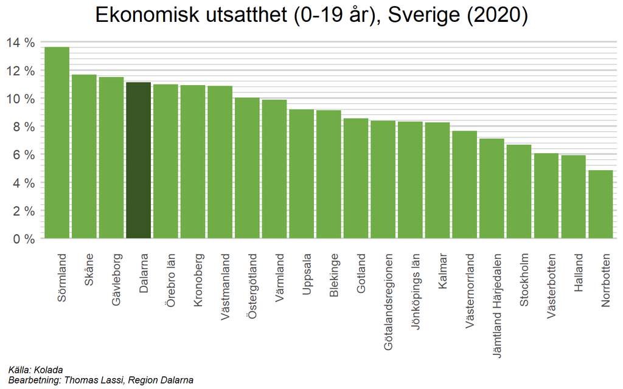

## Andel unga som upplever att de är delaktiga i sin kommun

Hållbar utveckling kräver förståelse för och kunskap om framtida generationers utmaningar och behov. FN:s konvention om barnets rättigheter, eller barnkonventionen som den ofta kallas, är svensk lag och syftar till att ge barn oavsett bakgrund rätt att behandlas med respekt och att få komma till tals. Barn och unga i Dalarna måste ges möjlighet att ta en aktiv del i samhällsutvecklingen för att målen i Dalastrategin ska kunna uppnås.

För att kunna följa utvecklingen på det här området inkluderas en indikator för ungas delaktighet i Dalastrategin. Data för indikatorn hämtas från ungdomsenkäten LUPP som genomförs vart tredje år. Här redovisas andelen unga som har angett ganska eller mycket stora möjligheter att föra fram sina åsikter till dem som bestämmer i kommunen.

Utvecklingen för denna indikator är sammantaget negativ. På gymnasienivå är andelen som har svarit att det finns möjligheter till delaktighet ungefär lika stor 2015 som 2021 (19,8 respektive 19,5 procent) även om det är en svag minskning. En tydligare trend finns bland högstadieungdomar där andelen som ser möjligheter till delaktighet har sjunkit från 23,4 till 19 procent.

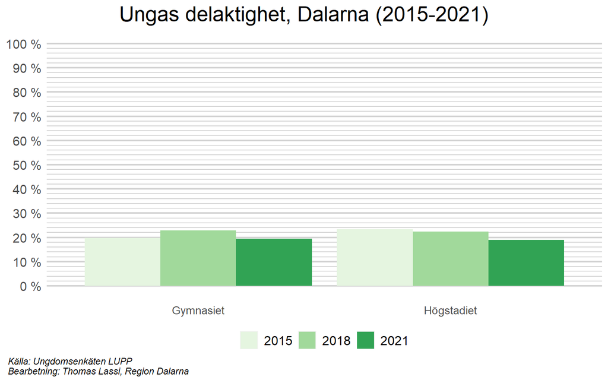

## Självskattad hälsa

Folkhälsan varierar hos befolkningen, både i riket och mellan platser i Dalarnas län. Personer med lägre utbildningsnivå har generellt sett en sämre hälsa och sämre förutsättningar för en god hälsa än de med högre utbildningsnivå. Självskattad hälsa är en av de indikatorer som Folkhälsomyndigheten har valt för att mäta folkhälsan och dess förutsättningar. Det är även en av indikatorerna som återfinns under avsnittet för ett sammanhållet Dalarna i Dalastrategin.

För 2021 var det totalt 69 procent av respondenterna i Dalarnas län som uppgav ett bra eller mycket bra allmänt hälsotillstånd. För tidsperioden 2014-2021 har det allmänna hälsotillståndet i länet varit stabilt runt 68-69 procent utan några större förändringar. Däremot framkommer det att en något större andel av män upplever ett bättre hälsotillstånd än kvinnliga respondenter.

I ett nationellt perspektiv ligger alla utom en kommun i Dalarnas län under riksgenomsnittet. Av befolkningen 16-84 år var det enligt 2021 års undersökning 74 procent som uppgav att de har en bra eller mycket bra hälsa. Även på nationell nivå är andelen högre bland män än bland kvinnor, och högre bland yngre jämfört med äldre. I Älvdalen uppgav 74 procent en god eller mycket bra hälsa och motsvarande siffra för Smedjebacken var 66 procent.

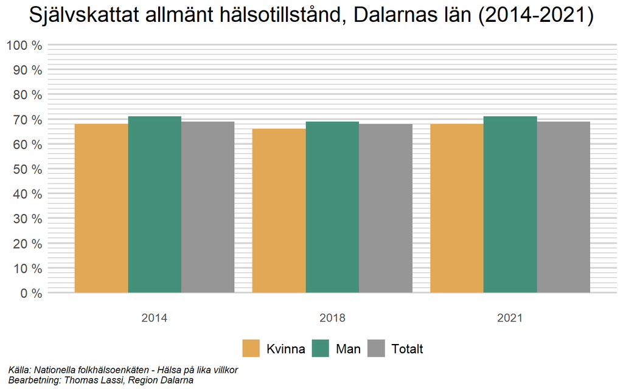

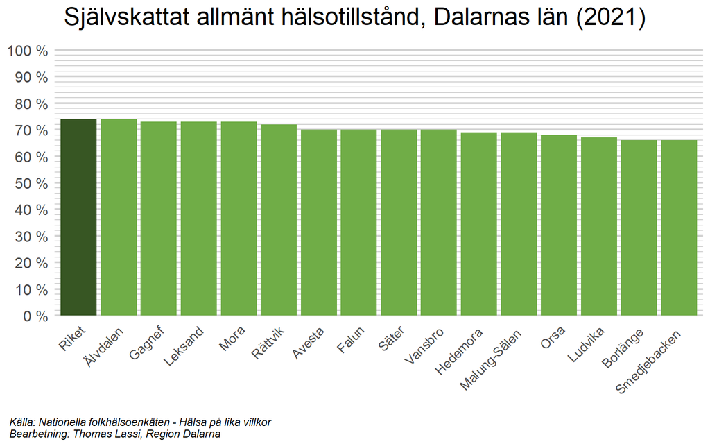